# Homework 3 Solutions

Due 11/11/2022 by 11:59pm EST

```r
library(tidyverse)
library(lubridate)
```

The 2009 H1N1 influenza pandemic, known more colloquially as the swine flu, swept much of the world between April 2009 and August 2010. First detected in the United States, the novel A(H1N1)pdm09 virus is most closely related to the North American swine-lineage H1N1 and Eurasian lineage swine-origin H1N1 influenza viruses. Unlike most seasonal influenza strains, it does not disproportionately infect adults older than 65. A vaccine was quickly developed and widely distributed by the late fall of 2009, but A(H1N1)pdm09 continues to circulate as a seasonal flu virus [[source]](https://www.cdc.gov/flu/pandemic-resources/2009-h1n1-pandemic.html).

In this homework, we will be analyzing data scraped from the Wikipedia article “2009 swine flu pandemic tables” [here](https://en.wikipedia.org/wiki/2009_swine_flu_pandemic_tables). The web page summarizes country-level information in two tables, one for A(H1N1)pdm09 cases and one for A(H1N1)pdm09 deaths. From April until July 5, 2009, the data was taken from the *Influenza A(H1N1) updates* issued roughly once every other day by the World Health Organization (WHO) [[source]](https://www.who.int/csr/disease/swineflu/updates/en/). Thereafter, the data was taken from the European Centre for Disease Prevention and Control (ECDC)’s *situation reports on Influenza A(H1N1)v*, which were published roughly three times a week [[archived source]](https://web.archive.org/web/20090812212650/http://www.ecdc.europa.eu/en/Health_topics/novel_influenza_virus/2009_Outbreak/). The ECDC stopped publishing case counts after August 9, 2009.

Load the data by running:

```r
load("h1n1_wiki_tables.rData")
```

Variables in `cases_df`:

- `by_date`: Used for sorting rows by date of first confirmed case
- `by_continent`: Used for sorting rows by date of first confirmed case by continent
- `country`: Country name
- `first_case`: Date of first confirmed A(H1N1)pdm09 case in the country, YYYY-MM-DD format
- `Apr`, `May`, `Jun`, `Jul`, `Aug`: Total number of confirmed A(H1N1)pdm09 cases on the first reported day of that month in 2009
- `latest`: Total number of confirmed cases on August 9, 2009, the last day that the ECDC published A(H1N1)pdm09 case totals

Variables in `deaths_df`:

- `by_date`: Used for sorting rows by date of first confirmed death
- `by_continent`: Used for sorting rows by date of first confirmed death by continent
- `country`: Country name
- `first_death`: Date of first A(H1N1)pdm09 death in the country, YYYY-MM-DD format
- `Apr`, `May`, `Jun`, `Jul`, `Aug`, `Sep`, `Oct`, `Nov`, `Dec`: Total number of A(H1N1)pdm09 deaths on the first reported day of that month in 2009
1. The first three rows of `cases_df` and the first two rows of `deaths_df` do not contain country-level information. (You can see this in the tables on the Wikipedia page, or you can check by running the `head` function on `cases_df` and `deaths_df`.) Drop these rows from your data frames.

**Solution:**

Check that the first three rows of of `cases_df` and the first two rows of `deaths_df` are not country-level.

```r
head(cases_df)
```

```
##   by_date by_continent                   country first_case Apr May   Jun   Jul
## 1       0         0.00                     World 2009-04-24  25 367 17398 77201
## 2       0         0.00   Days to double (approx)             NA   2    15    15
## 3       0         0.00 Countries and territories              2  13    63   121
## 4       1         1.01                    Mexico 2009-04-24  18 156  5029  8680
## 5       2         1.02  United States of America 2009-04-24   7 141  8975 27717
## 6       3         1.03                    Canada 2009-04-27  NA  34  1336  7983
##      Aug latest
## 1 188333 208269
## 2     28     29
## 3    168    175
## 4  16442  17530
## 5  43771  43771
## 6  10449  10449
```

```r
head(deaths_df)
```

```
##   by_date by_continent    country first_death Apr May Jun Jul  Aug  Sep  Oct
## 1       0         0.00      World  2009-04-27  NA  10 115 332 1265 3097 4433
## 2       0         0.00  Countries               0   2   4  17   45   69   83
## 3       1         1.01     Mexico  2009-04-27  NA   9  97 116  146  193  231
## 4       2         1.02        USA  2009-04-30  NA   1  15 127  353  556  593
## 5       3         1.03     Canada  2009-05-09  NA  NA   2  25   59   72   78
## 6       4         1.04 Costa Rica  2009-05-10  NA  NA   1   2   22   33   37
##    Nov  Dec
## 1 6153 8748
## 2   99  124
## 3  354  656
## 4 1004 1265
## 5   95  309
## 6   38   40
```

Drop the offending observations.

```r
cases_df <- cases_df %>% slice(4:n())
deaths_df <- deaths_df %>% slice(3:n())
```

2. The `first_case` column in the `cases_df` data frame contains the date of the first confirmed case in YYYY-MM-DD format, but it is stored as a character variable. Convert `first_case` to a date type variable.

**Solution:**

```r
cases_df <- cases_df %>% mutate(first_case = ymd(first_case))
```

3. Make a scatterplot of the number of cases reported by August 9, 2009 (the `latest` variable in `cases_df`) plotted against the date of the first confirmed case (the `first_case` variable, which you converted to a date type in Question 2). Based on this figure, would you say that the date of the first case is a good predictor for the number of cases on August 9?

**Solution:**

While there appears to be some connection between having an earlier first confirmed case and a higher case count, this is not a perfect predictor. There are many countries that have low case counts on August 9 despite having had their first case confirmed in May. There were probably other factors in play, such as population density or public health initiatives in different countries.

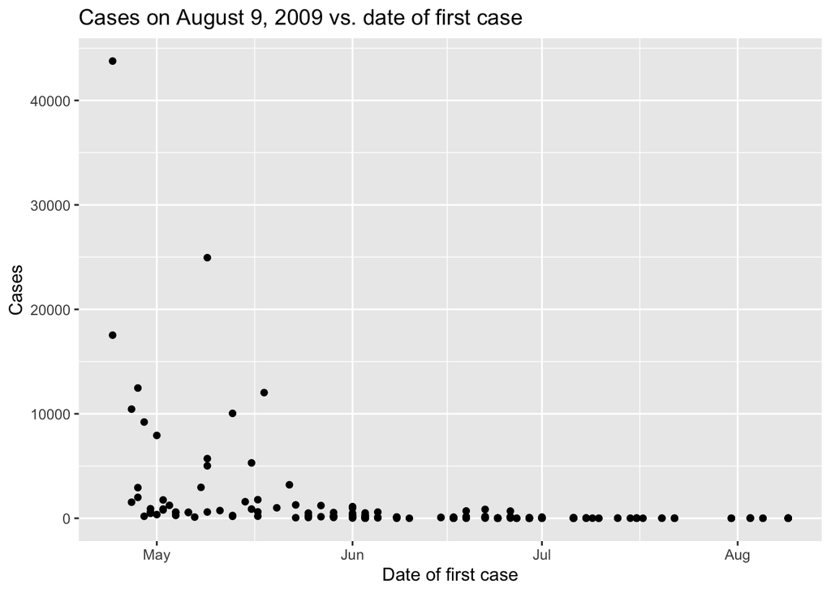

```r
ggplot(cases_df, aes(x = first_case, y = latest)) +
  geom_point() +
  labs(x ="Date of first case", y = "Cases",
       title="Cases on August 9, 2009 vs. date of first case")
```

4. Identify a transformation for the y-axis in your figure from Question 3 that makes it easier to see patterns and trends. Display the plot with your chosen transformation. If you wanted to run a linear regression model to predict the number of cases on August 9, 2009 based on the date of first case, would you prefer to use the transformed or untransformed data? Briefly explain why.

**Solution:**

We used a log (base 10) transformation of the y-axis, which makes it much easier to the variation for smaller case counts. There is also a clearer linear trend in the transformed data compared to the plot in Question 3, so we would prefer to fit a linear regression model to the transformed data.

Other transformations can be used; in particular, most log transformations (e.g. the natural log or other bases) will yield similar visualizations/conclusions.

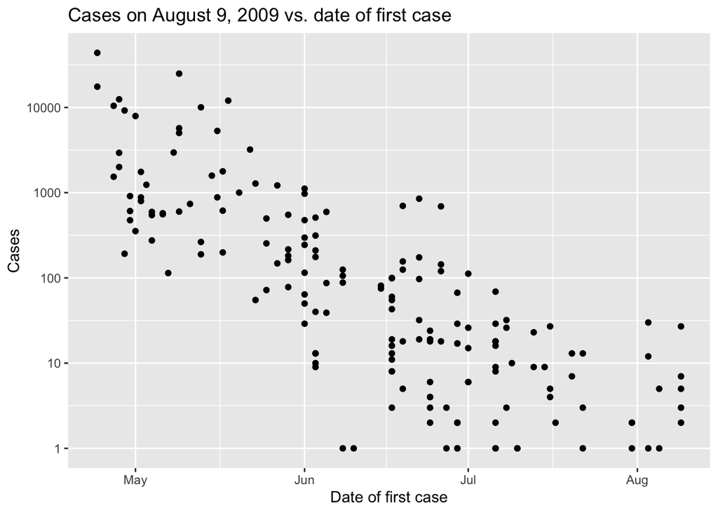

```r
ggplot(cases_df, aes(x=first_case, y=latest)) +
  geom_point() +
  labs(x ="Date of first case", y = "Cases",
       title="Cases on August 9, 2009 vs. date of first case") +
   scale_y_log10()
```

5. Reshape `cases_df` into a new data frame called `long_cases_df` by gathering the month columns `c("Apr", "May", "Jun", "Jul", "Aug")`. Set the month column names to a new variable in the data called `month`, and set the column cells (the cases for each month) to a new variable called `cases`. When you are done, `long_cases_df` should have two new columns (`month` and `cases`) and no columns that are named after months.

   Similarly, reshape `deaths_df` into a new data frame called `long_deaths_df` by gathering the month columns `c("Apr", "May", "Jun", "Jul", "Aug", "Sep", "Oct", "Nov", "Dec")`. Set the month column names to a new variable called `month`, and set the column cells (the deaths for each month) to a new variable called `deaths`.

**Solution:**

Note that `"Apr":"Aug"` tells `pivot_longer` to gather all of the columns between `"Apr"` and `"Aug"` in `cases_df`. It would have been equivalent (but longer) to pass in `c("Apr", "May", "Jun", "Jul", "Aug")` as the third argument.

```r
long_cases_df <- cases_df %>%
  pivot_longer("Apr":"Aug", names_to = "month", values_to = "cases")

long_deaths_df <- deaths_df %>%
  pivot_longer("Apr":"Dec", names_to = "month", values_to = "deaths")
```

6. In Question 7, we will combine `long_cases_df` with `long_deaths_df` to make a new data frame. But before we do that, we want to make the variables in the two data frames more consistent with each other. In `long_deaths_df`, recode “USA” in the `country` variable as “United States of America”.

**Solution:**

```r
long_deaths_df = long_deaths_df %>%
  mutate(country = recode(country, USA = "United States of America"))
```

7. Use the `inner_join` function to combine `long_cases_df` and `long_deaths_df` by country and month. Save the result as a new data frame called `combined_df`.

   Optional: Clean up `combined_df` by keeping only the relevant columns: `country`, `month`, `cases`, and `deaths`.

**Solution:**

```r
combined_df = inner_join(select(long_cases_df, country, month, cases),
                         select(long_deaths_df, country, month, deaths),
                         by = c("country", "month"))
```

8. Subset `combined_df` so that it only contains observations from the month of August, and drop all rows that contain missing values. Assign the result to a new data frame and report the number of rows it has. Hint: If you are working in the tidyverse, you can use the `drop_na` function to drop all rows that contain NAs.

**Solution:**

46 rows remain after subsetting the data to only include observations from August and dropping the rows with missing values.

```r
august_df = combined_df %>% filter(month=="Aug") %>% drop_na()
nrow(august_df)
```

```
## [1] 46
```

9. Using your subsetted data frame from Question 8, plot the number of deaths against the number of cases reported by August 2009. Describe the relationship between the two variables.

   Optional: Can you comment on a few specific countries and whether or not they seem to be following the general trend (perhaps by labeling some of the points in your plot or by making a table)?

**Solution:**

Many countries in this dataset have very few cases and deaths, so it is a little hard to tell what is going on with them. However, it seems that there is a positive relationship between the number of cases and deaths. Note that because these are raw counts, they do not take into account country population.

The United States stands out as an outlier: it has a very high number of both cases and deaths. Some countries, like Argentina and Brazil, have far higher death counts than their case counts would imply. The opposite is true for some of the other countries, like Australia and the United Kingdom.

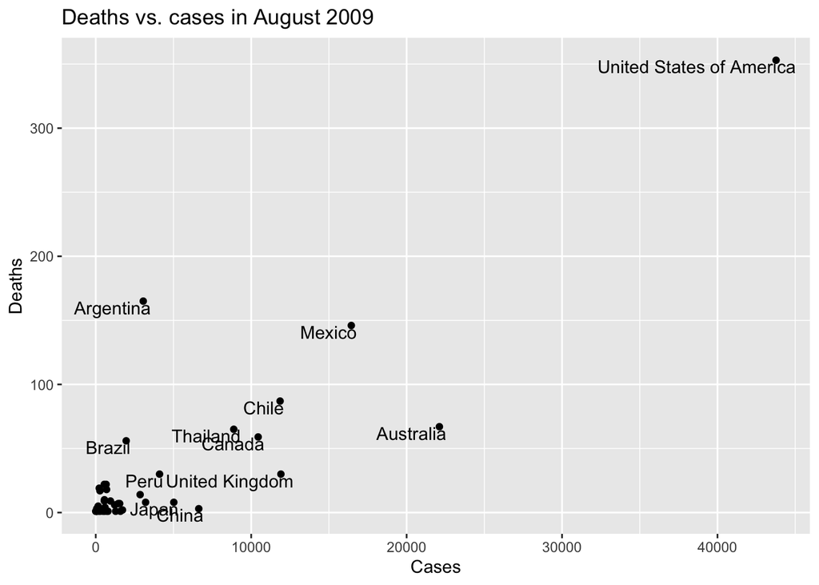

```r
ggplot(august_df, aes(x=cases, y=deaths)) + geom_point() +
  labs(x ="Cases", y = "Deaths",
       title="Deaths vs. cases in August 2009") +
  geom_text(data=subset(august_df, cases > 4000 | deaths > 40),
            aes(x=cases, y=deaths, label=country), hjust=0.9, vjust=1)
```

There are only 46 observations left in the dataset, so you could feasibly print it out to check which countries have disproportionately high/low death counts. The following code outputs the countries with the top 10 case counts, which is a little easier to read and interpret. For example, you can see that Mexico has more than twice the number of deaths as Australia, even though it has fewer cases.

```r
august_df %>% arrange(desc(cases)) %>% head(10)
```

```
## # A tibble: 10 × 4
##    country                  month cases deaths
##    <chr>                    <chr> <int>  <int>
##  1 United States of America Aug   43771    353
##  2 Australia                Aug   22109     67
##  3 Mexico                   Aug   16442    146
##  4 United Kingdom           Aug   11912     30
##  5 Chile                    Aug   11860     87
##  6 Canada                   Aug   10449     59
##  7 Thailand                 Aug    8879     65
##  8 China                    Aug    6628      3
##  9 Japan                    Aug    5022      8
## 10 Peru                     Aug    4104     30
```

10. Discuss the reliability of the A(H1N1)pdm09 data used in this assignment. This is an open-ended question, but if you are unsure of how to start, here are some points that you could consider:
- Do you trust the data sources?
- Is it problematic that the tables pull numbers from two different reporting sources?
- How difficult is it to confirm an A(H1N1)pdm09 case or death?
- Do you expect the same level of reporting accuracy in all countries?
- Do you expect the reported counts to be overestimates or underestimates of the true values?
- What other information (on data collection/reporting, or additional variables) would be useful to help you assess data reliability?

Please limit your response to no more than 1-2 paragraphs. You do not need to use outside sources, but if you do, be sure to cite them.

**Solution:**

A good response should discuss at least two different points/ideas (they do not need to come from the list supplied in the question) and provide some reasoning.